# Exploratory Analysis California WireTapping

Bukun

# 1 What is Wire Tapping ?

Wiretapping is the surreptitious electronic monitoring of telephone, telegraph, cellular, fax or Internet-based communications.

Wiretapping is achieved either through the placement of a monitoring device informally known as a bug on the wire in question or through built-in mechanisms in other communication technologies. Enforcement officials may tap into either for live monitoring or recording. Packet sniffers – programs used to capture data being transmitted on a network - are a commonly-used modern-day wiretapping tool. A variety of other tools, such as wiretap Trojans, are used for different applications.

Source : [WireTapping](http://whatis.techtarget.com/definition/wiretapping)

# 2 Cases by Jurisdiction

Analysis of the numbers of cases by Jurisdiction illustrates that **Los Angeles** , **Riverside** , **San Bernardino** are the TOP 3 areas where wire tapping is done.

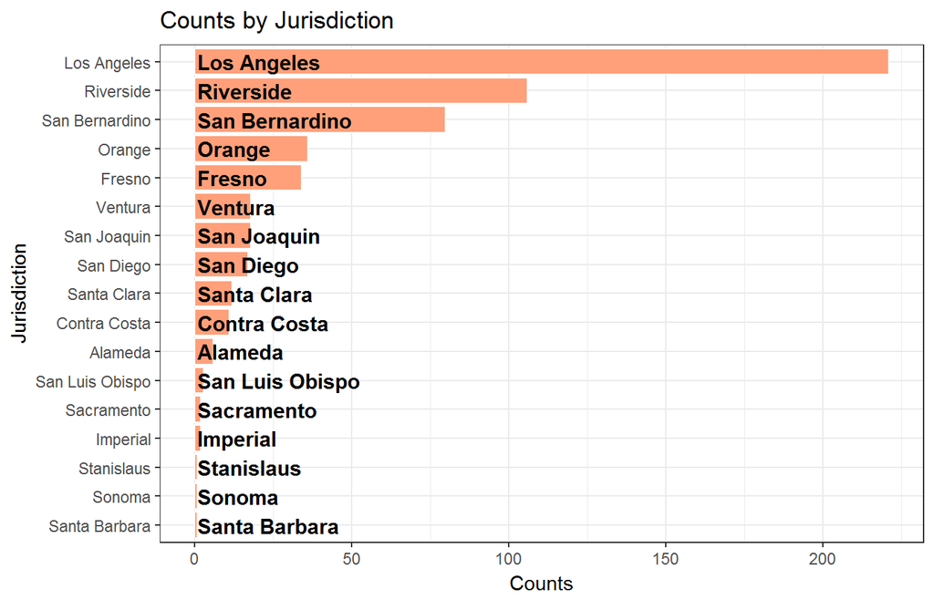

# 3 Cost Analysis by Jurisdiction

Analysis is done for the following perspectives :

1. Most Expensive Wire Tapping Cases
2. Total Cost for each jurisdiction
3. Personnel Cost for each jurisdiction
4. Resource Cost for each jurisdiction

## 3.1 Most Expensive Wire Tapping Cases

|  | EICOSNumber | Jurisdiction | Offense | TermDate | TotalCostIndividual | ResourceCost | PersonnelCost |
| --- | --- | --- | --- | --- | --- | --- | --- |
| 1 | 2016-LA-1225 | Los Angeles | Murder | 5/28/2016 | 1030000 | 30000 | 1000000 |
| 2 | 2016-SJ-83 | San Joaquin | Murder | 5/18/2016 | 727000 | 92000 | 635000 |
| 3 | 2016-LA-1268 | Los Angeles | Murder | 2/18/2016 | 658600 | 33600 | 625000 |
| 4 | 2016-LA-1267 | Los Angeles | Murder | 2/18/2016 | 657600 | 32600 | 625000 |
| 5 | 2016-SD-232 | San Diego | Narcotics | 7/18/2016 | 418211 | 50599 | 367612 |
| 6 | 2016-FR-23 | Fresno | Murder | 10/3/2016 | 368549 | 21750 | 346799 |

## 3.2 Total cost by Jurisdiction

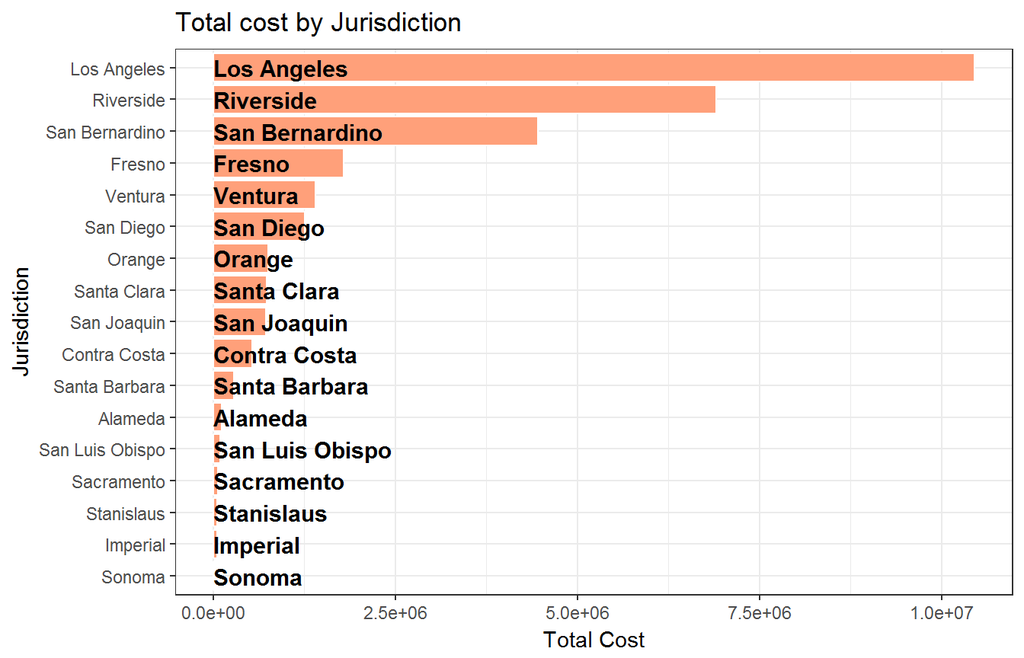

The graph illustrates that **Los Angeles** , **Riverside** , **San Bernardino** are the TOP 3 most expensive cities when accounting for the total cost of expenditure.

### 3.2.1 Exploration of the cost data

|  | Jurisdiction | TotalPersonnelCost | TotalResourceCost | TotalCost |
| --- | --- | --- | --- | --- |
| 1 | Los Angeles | 9700234 | 750261 | 10450495 |
| 2 | Riverside | 5867937 | 1034521 | 6902458 |
| 3 | San Bernardino | 4076002 | 384387 | 4460389 |
| 4 | Fresno | 1520155 | 268953 | 1789108 |
| 5 | Ventura | 1237877 | 164232 | 1402109 |
| 6 | San Diego | 1157233 | 101064 | 1258297 |

## 3.3 Personnel Cost by Jurisdiction

Following graph shows the Personnel cost by Jurisdiction for wire tapping.

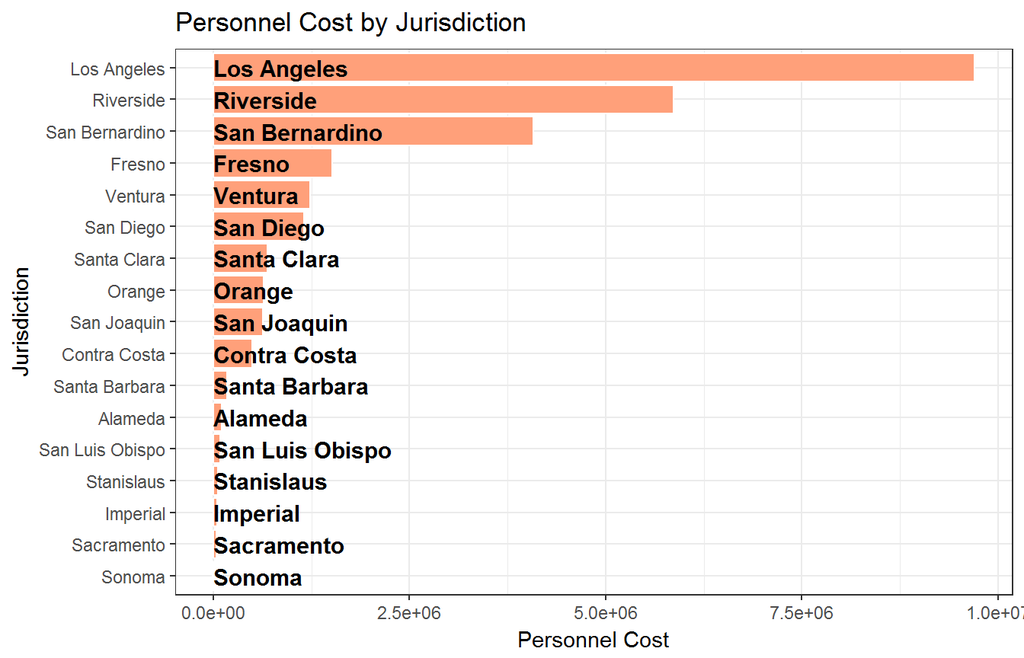

The graph illustrates that **Los Angeles** is the most expensive city for personnel cost.

## 3.4 Resource Cost by Jurisdiction

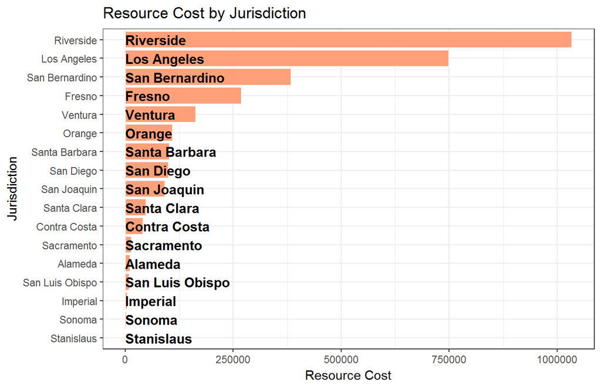

The graph illustrates that **Riverside** is the most expensive city for resource cost.

# 4 Cases by Offense

Narcotics, Murder , Gang and Human Trafficking are the offense categories with Narcotics being the main contributor in this category.

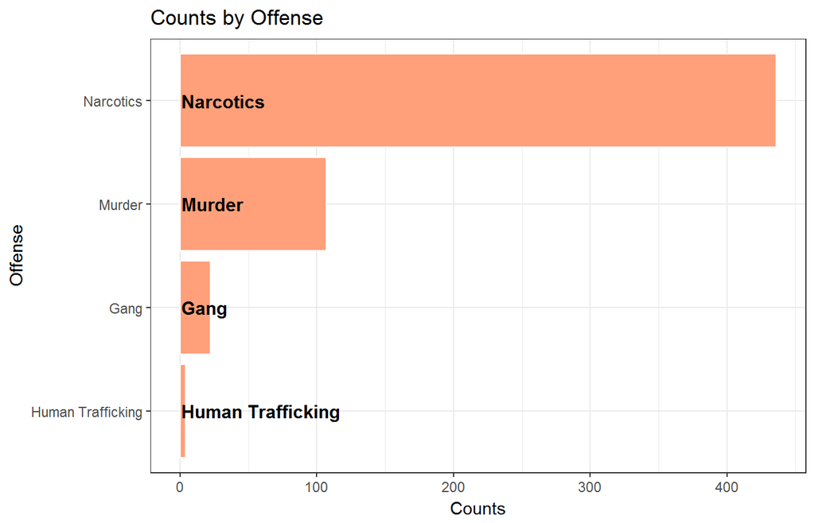

# 5 Cases per month

We investigate which is the most active month for investigation of the cases.Lowest number of cases are around Dec - Jan. This might be due to the holidays season in California.

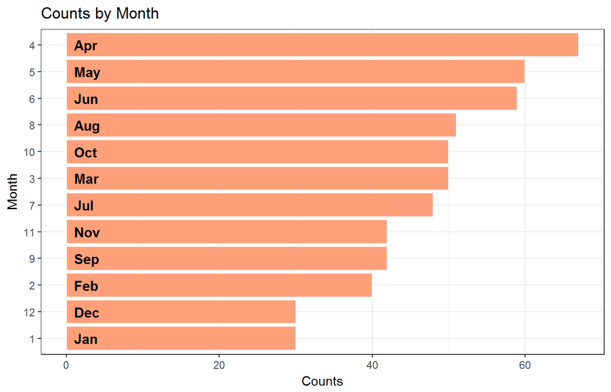

# 6 Most Active Judges

We investigate the most active Judges. The 1st , 2nd and 3rd positons go to **Judge Fidler ( 220 cases ) , Judge Dugan ( 105 cases) , Judge Powell ( 68 cases )**.

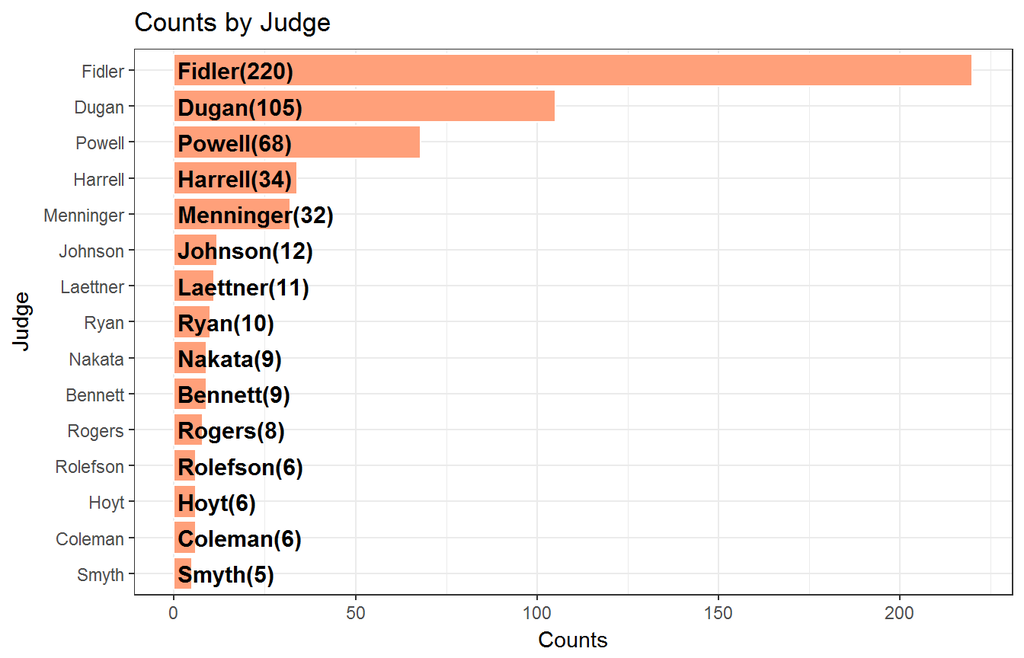

# 7 Most Active Prosecutors

We investigate the most active Prosecutors.The 1st , 2nd and 3rd positons go to **Prosecutor Lacey ( 221 cases ) , Prosecutor Bennet ( 90 cases) , Prosecutor Hoffman ( 37 cases )**.

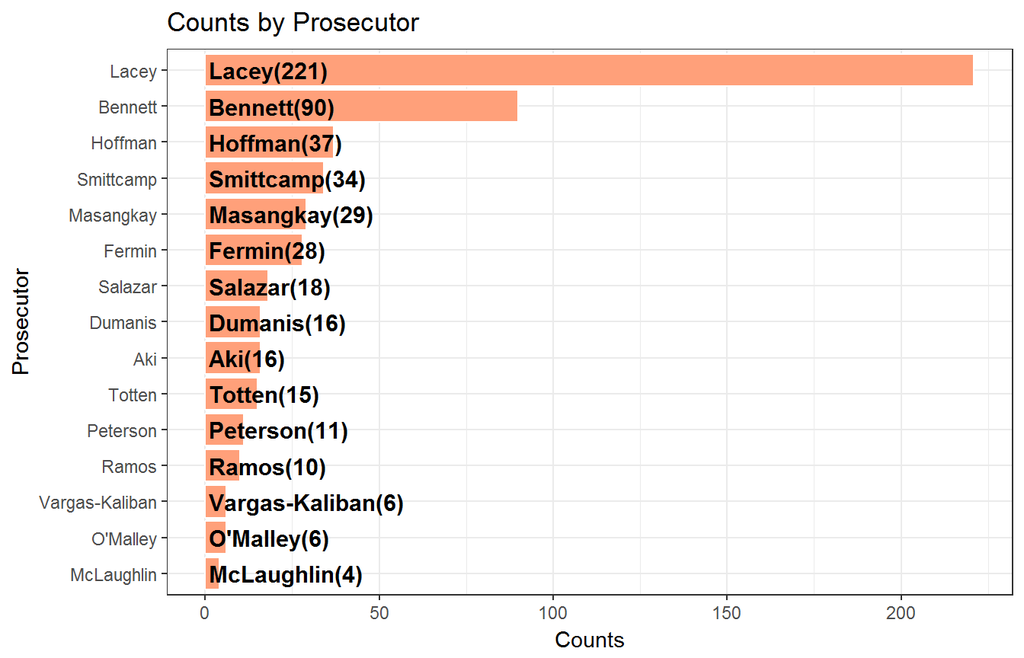

# 8 Investigate Total cost of investigation on other factors

We would like to investigate which factors influence the **Total Cost** of the investigation. For this we build a **XGBoost** model on the data so as to find the importance of the various factors on **Total Cost**.

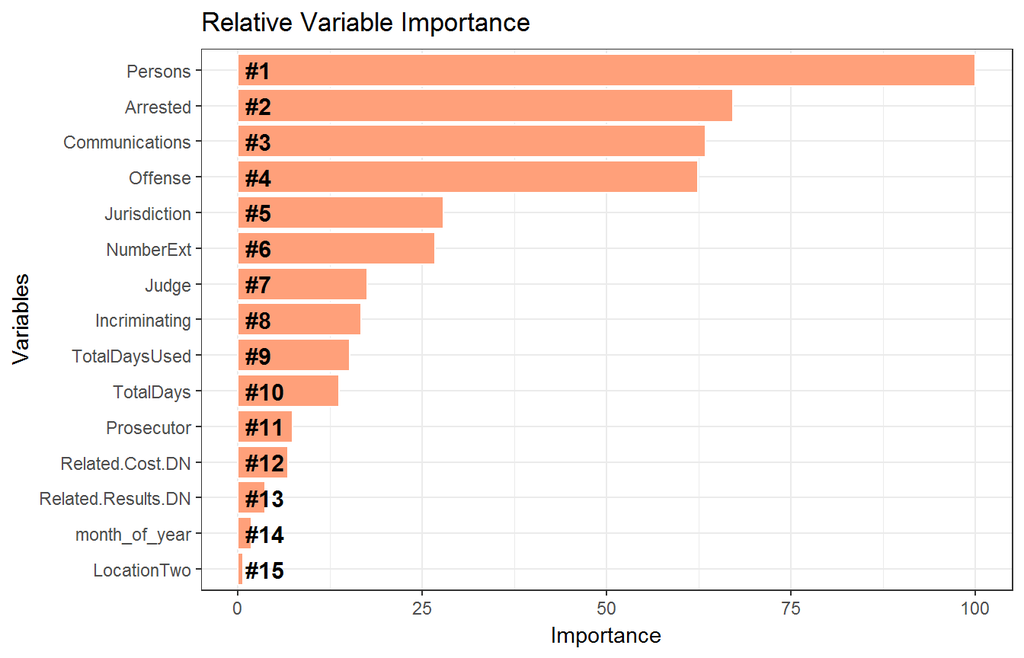

```r
transformdata = data %>% select (-c(EICOSNumber,DocketNumber,DocketYear,AONumber,
                                    ControlNumber,State,PersonnelCost,ResourceCost
                                    ,AppDate,AmdDate,TermDate))

features <- colnames(transformdata)

for (f in features) {
  if ((class(transformdata[[f]])=="factor") || (class(transformdata[[f]])=="character")) {
    levels <- unique(transformdata[[f]])
    transformdata[[f]] <- as.numeric(factor(transformdata[[f]], levels=levels))
  }
}

formula = TotalCostIndividual ~ .

fitControl <- trainControl(method="none")

xgbGrid <- expand.grid(nrounds = 500,
                       max_depth = 3,
                       eta = .05,
                       gamma = 0,
                       colsample_bytree = .8,
                       min_child_weight = 1,
                       subsample = 1)


set.seed(13)

WireTappingXGB = train(formula, data = transformdata,
                method = "xgbTree",trControl = fitControl,
                tuneGrid = xgbGrid,na.action = na.pass,metric="RMSE")

importance = varImp(WireTappingXGB)

varImportance <- data.frame(Variables = row.names(importance[[1]]),
                            Importance = round(importance[[1]]$Overall,2))

# Create a rank variable based on importance
rankImportance <- varImportance %>%
  mutate(Rank = paste0('#',dense_rank(desc(Importance))))

rankImportancefull = rankImportance

rankImportance =rankImportance[1:15,]

ggplot(rankImportance, aes(x = reorder(Variables, Importance),
                           y = Importance)) +
  geom_bar(stat='identity',colour="white", fill = fillColor) +
  geom_text(aes(x = Variables, y = 1, label = Rank),
            hjust=0, vjust=.5, size = 4, colour = 'black',
            fontface = 'bold') +
  labs(x = 'Variables', title = 'Relative Variable Importance') +
  coord_flip() +
  theme_bw()
```

The graph shows the factors ranked from 1 to 15 which affect the Total Cost of investigation.

The top 3 factors include

1. Number of **Persons**
2. Number of **People** Arrested
3. Number of **Communications** done

All the factors affecting the **Total Cost** along with their ranks is provided below

|  | Variables | Importance | Rank |
| --- | --- | --- | --- |
| 1 | Persons | 100 | #1 |
| 2 | Arrested | 67.11 | #2 |
| 3 | Communications | 63.38 | #3 |
| 4 | Offense | 62.36 | #4 |
| 5 | Jurisdiction | 27.84 | #5 |
| 6 | NumberExt | 26.73 | #6 |
| 7 | Judge | 17.49 | #7 |
| 8 | Incriminating | 16.69 | #8 |
| 9 | TotalDaysUsed | 15.17 | #9 |
| 10 | TotalDays | 13.73 | #10 |

[output cut: 16 more lines]

# 9 Relation between Total Cost per Case vs. Number of Persons per case.

The total cost of a case increases with the number of persons associated with the case.

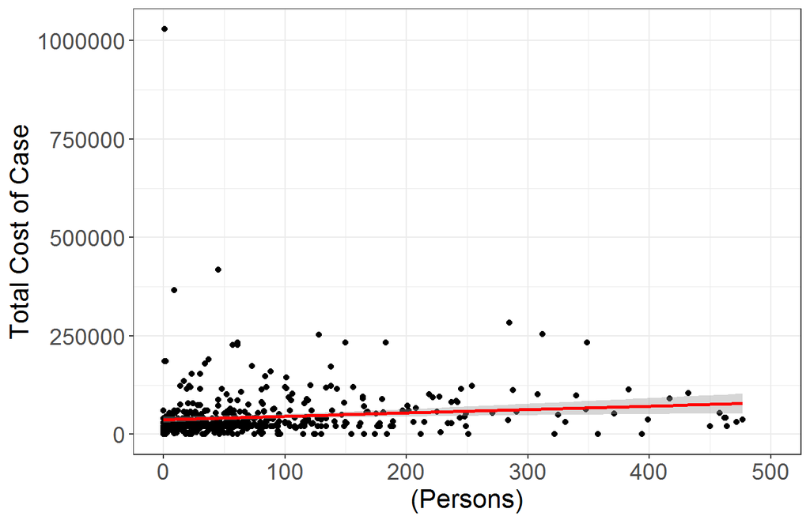

# 10 Relation between Total Cost per Case vs. Number of Arrested per case.

The total cost of a case increases with the number of persons arrested for the case.

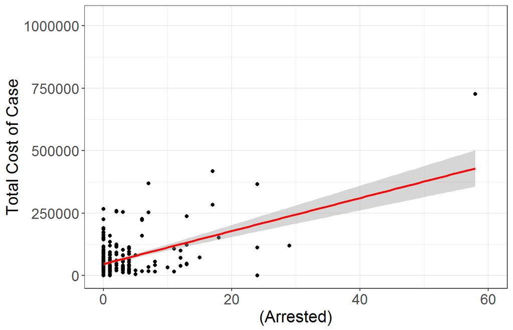

# 11 Relation between Total Cost per Case vs. Number of Communications per case.

The total cost of a case increases with the number of communications for the case.

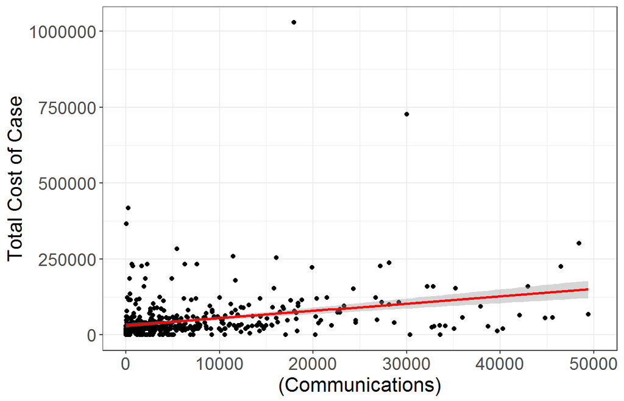

# 12 Acknowledgements

I am learning everyday from the Kagglers. I would like to specially mention the following from whom I have been inspired

- **Philipp Spachtholz**
- **Megan Risdal**

If you like the EDA, please upvote. Drop in your suggestions so that I may improve on the same.